# act_report

## Act Report for Data Wrangling Project

### Introduction

The Data Wrangling Project was given to us to gather, assess and clean the WeRateDogs dataset. All these steps have been carried out and useful insights have been generated from this project.

### Insights and Visualizations.

Insights have been generated from my analysis wjich I will be listing below:

- Most Liked Dogs
- The Dogs with the highest retweets.
- Most Favorite Dog Breeds
- The Most Popular Dog Breeds
- The Most Favorite Dog stage

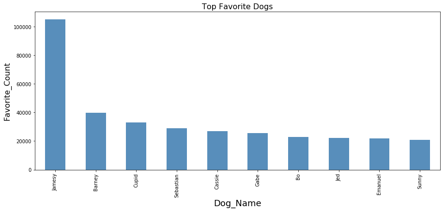

The analysis reveals the top 10 names of the most liked dogs. Jamesy is the name of the dog that has the highest likes in the WeRateDogs dataset. Barney is the second most liked dog, while Cupid comes third.

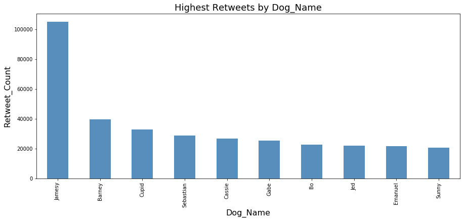

The top 10 dogs with the highest retweets can be seen in the graph above, and Jamesy has the highest retweets. We can see from the visualization above that it is similar to the most favorite dogs. It could be that dogs that are most loved have the highest retweets.

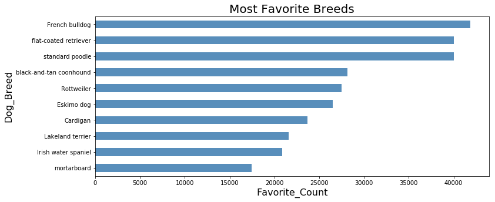

We can see the top 10 most favorite dog breeds in the visualization above. The French Bulldog is the most favorite dog breed in this category, having over 40,000 likes, while the flat_coated retriever is the second most liked breed.

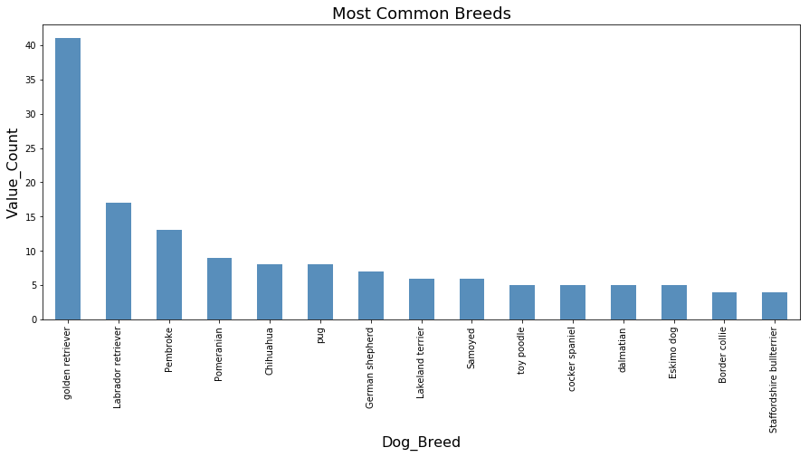

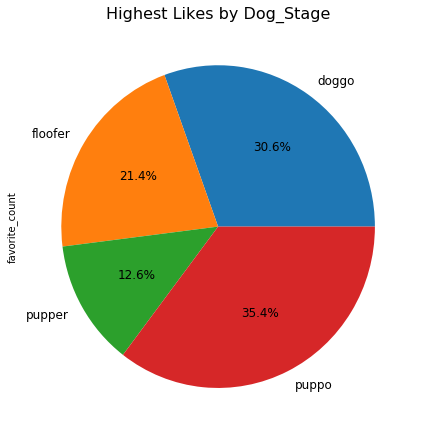

The pie chart displays the percentages of dog stages according to their favorite_counts. The puppo dog stage is the most loved stage in this category, having about 35.4% of the total, while the doggo is the second most loved dog stage.